# Solutions for week03

Author

Jarkko Toivonen

Published

February 28, 2026

```r
library(flowCore)
library(magrittr)
library(glue)
library(tibble)
library(dplyr)
library(tidyr)
library(stringr)
library(purrr)
library(ggplot2)

# Default printing causes problems when there are dollar signs in the table.
# In those cases use the below function instead of the default method
mykable <- function(df) knitr::kable(df, escape = TRUE, format = "html")
```

Helper function.

```r
get_spill <- function(flow_frame)
{
    dl <- flow_frame@description
    if ("$SPILLOVER" %in% names(dl)) {
        return(dl[["$SPILLOVER"]])
    } else if ("SPILL" %in% names(dl)) {
        return(dl[["SPILL"]])
    } else {
        return(NULL)
    }

}
```

## Problem 1

> Today’s walkthrough focused on a raw spectral flow cytometry file. Within a subfolder in data you will also find an unmixed .fcs file (2025_07_26…). Using what learned to day, investigate it, and see if you can catalog the main differences that occured to the keyword, parameters and exprs. Did any keywords get added, changed, deleted entirely? etc.

```r
filename1 <- "data/CellCounts4L_AB_05_ND050_05.fcs"
filename2 <- "data/AdditionalFCSFiles/2025_07_26_AB_02_NY068_02_Ctrl.fcs"
```

```r
flow_frame1 <- read.FCS(filename=filename1, transformation = FALSE, truncate_max_range = FALSE)
flow_frame2 <- read.FCS(filename=filename2, transformation = FALSE, truncate_max_range = FALSE)
```

```r
flow_frame1
```

```
flowFrame object 'CellCounts4L_AB_05-ND050-05.fcs'
with 100 cells and 61 observables:
       name   desc     range  minRange  maxRange
$P1    Time     NA    272140         0    272139
$P2   UV1-A     NA   4194304      -111   4194303
$P3   UV2-A     NA   4194304      -111   4194303
$P4   UV3-A     NA   4194304      -111   4194303
$P5   UV4-A     NA   4194304      -111   4194303
...     ...    ...       ...       ...       ...
$P57   R4-A     NA   4194304      -111   4194303
$P58   R5-A     NA   4194304      -111   4194303
$P59   R6-A     NA   4194304      -111   4194303
$P60   R7-A     NA   4194304      -111   4194303
$P61   R8-A     NA   4194304      -111   4194303
476 keywords are stored in the 'description' slot
```

MFI = mean/median fluorescence intensity

```r
flow_frame2
```

```
flowFrame object '2025_07_26_AB_02_NY068_02_Ctrl.fcs'
with 100 cells and 43 observables:
               name      desc     range  minRange    maxRange
$P1            Time        NA    516839         0     506.501
$P2           SSC-W        NA   4194304         0 4194303.000
$P3           SSC-H        NA   4194304         0 4194303.000
$P4           SSC-A        NA   4194304         0 4194303.000
$P5           FSC-W        NA   4194304         0 4194303.000
...             ...       ...       ...       ...         ...
$P39     APC-R700-A    CD107a   4194304      -111     4192506
$P40   Zombie NIR-A Viability   4194304      -111     4192506
$P41 APC-Fire 750-A      CD27   4194304      -111     4192506
$P42 APC-Fire 810-A      CCR7   4194304      -111     4192506
$P43           AF-A        NA   4194304      -111     4194303
472 keywords are stored in the 'description' slot
```

### exprs

```r
e1 <- exprs(flow_frame1)
e2 <- exprs(flow_frame2)
```

```r
glue("file1: expr has {ncol(e1)} observables and {nrow(e1)} cells\n")
```

```
file1: expr has 61 observables and 100 cells
```

```r
glue("file2: expr has {ncol(e2)} observables and {nrow(e2)} cells\n")
```

```
file2: expr has 43 observables and 100 cells
```

The column names differ, but the index names of column names are the same:

```r
df1 <- tibble(id = names(colnames(e1)), name1 = colnames(e1))
df2 <- tibble(id = names(colnames(e2)), name2 = colnames(e2))
df <- full_join(df1, df2, by="id")
mykable(df)
```

| id | name1 | name2 |
| --- | --- | --- |
| $P1N | Time | Time |
| $P2N | UV1-A | SSC-W |
| $P3N | UV2-A | SSC-H |
| $P4N | UV3-A | SSC-A |
| $P5N | UV4-A | FSC-W |
| $P6N | UV5-A | FSC-H |
| $P7N | UV6-A | FSC-A |
| $P8N | UV7-A | SSC-B-W |
| $P9N | UV8-A | SSC-B-H |
| $P10N | UV9-A | SSC-B-A |
| $P11N | UV10-A | BUV395-A |
| $P12N | UV11-A | BUV563-A |
| $P13N | UV12-A | BUV615-A |
| $P14N | UV13-A | BUV661-A |
| $P15N | UV14-A | BUV737-A |
| $P16N | UV15-A | BUV805-A |
| $P17N | UV16-A | Pacific Blue-A |
| $P18N | SSC-H | BV480-A |
| $P19N | SSC-A | BV570-A |
| $P20N | V1-A | BV605-A |
| $P21N | V2-A | BV650-A |
| $P22N | V3-A | BV711-A |
| $P23N | V4-A | BV750-A |
| $P24N | V5-A | BV786-A |
| $P25N | V6-A | Alexa Fluor 488-A |
| $P26N | V7-A | Spark Blue 550-A |
| $P27N | V8-A | Spark Blue 574-A |
| $P28N | V9-A | RB613-A |
| $P29N | V10-A | RB705-A |
| $P30N | V11-A | RB780-A |
| $P31N | V12-A | PE-A |
| $P32N | V13-A | PE-Dazzle594-A |
| $P33N | V14-A | PE-Cy5-A |
| $P34N | V15-A | PE-Fire 700-A |
| $P35N | V16-A | PE-Fire 744-A |
| $P36N | FSC-H | PE-Vio770-A |
| $P37N | FSC-A | APC-A |
| $P38N | SSC-B-H | Alexa Fluor 647-A |
| $P39N | SSC-B-A | APC-R700-A |
| $P40N | B1-A | Zombie NIR-A |
| $P41N | B2-A | APC-Fire 750-A |
| $P42N | B3-A | APC-Fire 810-A |
| $P43N | B4-A | AF-A |
| $P44N | B5-A | NA |
| $P45N | B6-A | NA |
| $P46N | B7-A | NA |
| $P47N | B8-A | NA |
| $P48N | B9-A | NA |
| $P49N | B10-A | NA |
| $P50N | B11-A | NA |
| $P51N | B12-A | NA |
| $P52N | B13-A | NA |
| $P53N | B14-A | NA |
| $P54N | R1-A | NA |
| $P55N | R2-A | NA |
| $P56N | R3-A | NA |
| $P57N | R4-A | NA |
| $P58N | R5-A | NA |
| $P59N | R6-A | NA |
| $P60N | R7-A | NA |
| $P61N | R8-A | NA |

### Parameters

#### varMetadata

The varMetadata of the parameters are the same for flow frames:

```r
parameters(flow_frame1)@varMetadata
```

|  | labelDescription |
| --- | --- |
| name | Name of Parameter |
| desc | Description of Parameter |
| range | Range of Parameter |
| minRange | Minimum Parameter Value after Transforamtion |
| maxRange | Maximum Parameter Value after Transformation |

```r
parameters(flow_frame2)@varMetadata
```

|  | labelDescription |
| --- | --- |
| name | Name of Parameter |
| desc | Description of Parameter |
| range | Range of Parameter |
| minRange | Minimum Parameter Value after Transforamtion |
| maxRange | Maximum Parameter Value after Transformation |

#### data

In the parameters@data slot the range columns are the same except for Time. For other columns there are differences.

```r
x <- full_join(
    as_tibble(parameters(flow_frame1)@data, rownames="id") %>% select(-desc),
    as_tibble(parameters(flow_frame2)@data, rownames="id"), # %>% select(-desc),
    by="id", suffix = c("_1", "_2")) %>%
    relocate(id, name_1, name_2, desc_2=desc, range_1, range_2, minRange_1, minRange_2, maxRange_1, maxRange_2)
mykable(x)
```

| id | name_1 | name_2 | desc_2 | range_1 | range_2 | minRange_1 | minRange_2 | maxRange_1 | maxRange_2 |
| --- | --- | --- | --- | --- | --- | --- | --- | --- | --- |
| $P1 | Time | Time | NA | 272140 | 516839 | 0.00000 | 0.0000 | 272139 | 506.5013 |
| $P2 | UV1-A | SSC-W | NA | 4194304 | 4194304 | -111.00000 | 0.0000 | 4194303 | 4194303.0000 |
| $P3 | UV2-A | SSC-H | NA | 4194304 | 4194304 | -111.00000 | 0.0000 | 4194303 | 4194303.0000 |
| $P4 | UV3-A | SSC-A | NA | 4194304 | 4194304 | -111.00000 | 0.0000 | 4194303 | 4194303.0000 |
| $P5 | UV4-A | FSC-W | NA | 4194304 | 4194304 | -111.00000 | 0.0000 | 4194303 | 4194303.0000 |
| $P6 | UV5-A | FSC-H | NA | 4194304 | 4194304 | -111.00000 | 0.0000 | 4194303 | 4194303.0000 |
| $P7 | UV6-A | FSC-A | NA | 4194304 | 4194304 | -111.00000 | 0.0000 | 4194303 | 4194303.0000 |
| $P8 | UV7-A | SSC-B-W | NA | 4194304 | 4194304 | -26.34649 | 0.0000 | 4194303 | 4194303.0000 |
| $P9 | UV8-A | SSC-B-H | NA | 4194304 | 4194304 | -111.00000 | 0.0000 | 4194303 | 4194303.0000 |
| $P10 | UV9-A | SSC-B-A | NA | 4194304 | 4194304 | 0.00000 | 0.0000 | 4194303 | 4194303.0000 |
| $P11 | UV10-A | BUV395-A | CD62L | 4194304 | 4194304 | -111.00000 | -111.0001 | 4194303 | 4192505.7500 |
| $P12 | UV11-A | BUV563-A | CD69 | 4194304 | 4194304 | -111.00000 | -111.0001 | 4194303 | 4192505.7500 |
| $P13 | UV12-A | BUV615-A | CCR4 | 4194304 | 4194304 | -111.00000 | -111.0001 | 4194303 | 4192505.7500 |
| $P14 | UV13-A | BUV661-A | Vd2 | 4194304 | 4194304 | -111.00000 | -111.0001 | 4194303 | 4192505.7500 |
| $P15 | UV14-A | BUV737-A | CD38 | 4194304 | 4194304 | -111.00000 | -111.0001 | 4194303 | 4192505.7500 |
| $P16 | UV15-A | BUV805-A | CD4 | 4194304 | 4194304 | -111.00000 | -111.0001 | 4194303 | 4192505.7500 |
| $P17 | UV16-A | Pacific Blue-A | Dump | 4194304 | 4194304 | -111.00000 | -111.0001 | 4194303 | 4192505.7500 |
| $P18 | SSC-H | BV480-A | CD161 | 4194304 | 4194304 | 0.00000 | -111.0001 | 4194303 | 4192505.7500 |
| $P19 | SSC-A | BV570-A | CD16 | 4194304 | 4194304 | 0.00000 | -111.0001 | 4194303 | 4192505.7500 |
| $P20 | V1-A | BV605-A | CD45RA | 4194304 | 4194304 | -111.00000 | -111.0001 | 4194303 | 4192505.7500 |
| $P21 | V2-A | BV650-A | CD8 | 4194304 | 4194304 | -111.00000 | -111.0001 | 4194303 | 4192505.7500 |
| $P22 | V3-A | BV711-A | Va7.2 | 4194304 | 4194304 | -111.00000 | -111.0001 | 4194303 | 4192505.7500 |
| $P23 | V4-A | BV750-A | IFNg | 4194304 | 4194304 | -111.00000 | -111.0001 | 4194303 | 4192505.7500 |
| $P24 | V5-A | BV786-A | CCR6 | 4194304 | 4194304 | -111.00000 | -111.0001 | 4194303 | 4192505.7500 |
| $P25 | V6-A | Alexa Fluor 488-A | FoxP3 | 4194304 | 4194304 | -111.00000 | -111.0001 | 4194303 | 4192505.7500 |
| $P26 | V7-A | Spark Blue 550-A | CD3 | 4194304 | 4194304 | -111.00000 | -111.0001 | 4194303 | 4192505.7500 |
| $P27 | V8-A | Spark Blue 574-A | CD45 | 4194304 | 4194304 | -111.00000 | -111.0001 | 4194303 | 4192505.7500 |
| $P28 | V9-A | RB613-A | PD1 | 4194304 | 4194304 | -111.00000 | -111.0001 | 4194303 | 4192505.7500 |
| $P29 | V10-A | RB705-A | CD26 | 4194304 | 4194304 | -111.00000 | -111.0001 | 4194303 | 4192505.7500 |
| $P30 | V11-A | RB780-A | CXCR5 | 4194304 | 4194304 | -111.00000 | -111.0001 | 4194303 | 4192505.7500 |
| $P31 | V12-A | PE-A | ICOS | 4194304 | 4194304 | -111.00000 | -111.0001 | 4194303 | 4192505.7500 |
| $P32 | V13-A | PE-Dazzle594-A | TNFa | 4194304 | 4194304 | -111.00000 | -111.0001 | 4194303 | 4192505.7500 |
| $P33 | V14-A | PE-Cy5-A | CXCR3 | 4194304 | 4194304 | -111.00000 | -111.0001 | 4194303 | 4192505.7500 |
| $P34 | V15-A | PE-Fire 700-A | CD127 | 4194304 | 4194304 | -111.00000 | -111.0001 | 4194303 | 4192505.7500 |
| $P35 | V16-A | PE-Fire 744-A | CD25 | 4194304 | 4194304 | -111.00000 | -111.0001 | 4194303 | 4192505.7500 |
| $P36 | FSC-H | PE-Vio770-A | HLA-DR | 4194304 | 4194304 | 0.00000 | -111.0001 | 4194303 | 4192505.7500 |
| $P37 | FSC-A | APC-A | CD39 | 4194304 | 4194304 | 0.00000 | -111.0001 | 4194303 | 4192505.7500 |
| $P38 | SSC-B-H | Alexa Fluor 647-A | IL-2 | 4194304 | 4194304 | 0.00000 | -111.0001 | 4194303 | 4192505.7500 |
| $P39 | SSC-B-A | APC-R700-A | CD107a | 4194304 | 4194304 | 0.00000 | -111.0001 | 4194303 | 4192505.7500 |
| $P40 | B1-A | Zombie NIR-A | Viability | 4194304 | 4194304 | -111.00000 | -111.0001 | 4194303 | 4192505.7500 |
| $P41 | B2-A | APC-Fire 750-A | CD27 | 4194304 | 4194304 | -111.00000 | -111.0001 | 4194303 | 4192505.7500 |
| $P42 | B3-A | APC-Fire 810-A | CCR7 | 4194304 | 4194304 | -111.00000 | -111.0001 | 4194303 | 4192505.7500 |
| $P43 | B4-A | AF-A | NA | 4194304 | 4194304 | -111.00000 | -111.0000 | 4194303 | 4194303.0000 |
| $P44 | B5-A | NA | NA | 4194304 | NA | -111.00000 | NA | 4194303 | NA |
| $P45 | B6-A | NA | NA | 4194304 | NA | 0.00000 | NA | 4194303 | NA |
| $P46 | B7-A | NA | NA | 4194304 | NA | -111.00000 | NA | 4194303 | NA |
| $P47 | B8-A | NA | NA | 4194304 | NA | -111.00000 | NA | 4194303 | NA |
| $P48 | B9-A | NA | NA | 4194304 | NA | -111.00000 | NA | 4194303 | NA |
| $P49 | B10-A | NA | NA | 4194304 | NA | -111.00000 | NA | 4194303 | NA |
| $P50 | B11-A | NA | NA | 4194304 | NA | -111.00000 | NA | 4194303 | NA |
| $P51 | B12-A | NA | NA | 4194304 | NA | -111.00000 | NA | 4194303 | NA |
| $P52 | B13-A | NA | NA | 4194304 | NA | -111.00000 | NA | 4194303 | NA |
| $P53 | B14-A | NA | NA | 4194304 | NA | -111.00000 | NA | 4194303 | NA |
| $P54 | R1-A | NA | NA | 4194304 | NA | -111.00000 | NA | 4194303 | NA |
| $P55 | R2-A | NA | NA | 4194304 | NA | -111.00000 | NA | 4194303 | NA |
| $P56 | R3-A | NA | NA | 4194304 | NA | -111.00000 | NA | 4194303 | NA |
| $P57 | R4-A | NA | NA | 4194304 | NA | -111.00000 | NA | 4194303 | NA |
| $P58 | R5-A | NA | NA | 4194304 | NA | -111.00000 | NA | 4194303 | NA |
| $P59 | R6-A | NA | NA | 4194304 | NA | -111.00000 | NA | 4194303 | NA |
| $P60 | R7-A | NA | NA | 4194304 | NA | -111.00000 | NA | 4194303 | NA |
| $P61 | R8-A | NA | NA | 4194304 | NA | -111.00000 | NA | 4194303 | NA |

#### dimLabels and classVersion

No differences in the dimLabels and **classVersion** slots:

```r
flow_frame1@parameters@dimLabels
```

```
[1] "rowNames"    "columnNames"
```

```r
flow_frame2@parameters@dimLabels
```

```
[1] "rowNames"    "columnNames"
```

```r
flow_frame1@parameters@.__classVersion__
```

```
AnnotatedDataFrame
           "1.1.0"
```

```r
flow_frame2@parameters@.__classVersion__
```

```
AnnotatedDataFrame
           "1.1.0"
```

### Description

```r
dl1 <- keyword(flow_frame1)
dl2 <- keyword(flow_frame2)
```

```r
names(dl1)
```

```
  [1] "$BEGINANALYSIS"     "$BEGINDATA"         "$BEGINSTEXT"
  [4] "$BTIM"              "$BYTEORD"           "$CYT"
  [7] "$CYTOLIB_VERSION"   "$CYTSN"             "$DATATYPE"
 [10] "$DATE"              "$ENDANALYSIS"       "$ENDDATA"
 [13] "$ENDSTEXT"          "$ETIM"              "$FIL"
 [16] "$INST"              "$MODE"              "$NEXTDATA"
 [19] "$OP"                "$P10B"              "$P10E"
 [22] "$P10N"              "$P10R"              "$P10TYPE"
 [25] "$P10V"              "$P11B"              "$P11E"
 [28] "$P11N"              "$P11R"              "$P11TYPE"
 [31] "$P11V"              "$P12B"              "$P12E"
 [34] "$P12N"              "$P12R"              "$P12TYPE"
 [37] "$P12V"              "$P13B"              "$P13E"
 [40] "$P13N"              "$P13R"              "$P13TYPE"
 [43] "$P13V"              "$P14B"              "$P14E"
```

[output cut: 144 more lines]

```r
names(dl2)
```

```
  [1] "$BEGINANALYSIS"     "$BEGINDATA"         "$BEGINSTEXT"
  [4] "$BTIM"              "$BYTEORD"           "$CYT"
  [7] "$CYTOLIB_VERSION"   "$CYTSN"             "$DATATYPE"
 [10] "$DATE"              "$ENDANALYSIS"       "$ENDDATA"
 [13] "$ENDSTEXT"          "$ETIM"              "$FIL"
 [16] "$INST"              "$MODE"              "$NEXTDATA"
 [19] "$OP"                "$P10B"              "$P10E"
 [22] "$P10N"              "$P10R"              "$P10TYPE"
 [25] "$P10V"              "$P11B"              "$P11E"
 [28] "$P11N"              "$P11R"              "$P11S"
 [31] "$P11TYPE"           "$P11V"              "$P12B"
 [34] "$P12E"              "$P12N"              "$P12R"
 [37] "$P12S"              "$P12TYPE"           "$P12V"
 [40] "$P13B"              "$P13E"              "$P13N"
 [43] "$P13R"              "$P13S"              "$P13TYPE"
```

[output cut: 143 more lines]

```r
glue("file1: description list contains {length(dl1)} keywords")
```

```
file1: description list contains 476 keywords
```

```r
glue("file2: description list contains {length(dl2)} keywords")
```

```
file2: description list contains 472 keywords
```

#### Metadata

Eight metadata values changed:

```r
init1 <- dl1[1:19]
init2 <- dl2[1:19]
x1 <- dl1[1:19] %>% enframe() %>% unnest(value)
x2 <- dl2[1:19] %>% enframe() %>% unnest(value)
df <- inner_join(x1, x2, by="name")
df %>% filter(value.x != value.y) %>% mykable()
```

| name | value.x | value.y |
| --- | --- | --- |
| $BEGINDATA | 33312 | 18357 |
| $BTIM | 13:55:29.85 | 21:30:10.27 |
| $CYTSN | V0333 | U1368 |
| $DATE | 04-Aug-2025 | 26-Jul-2025 |
| $ENDDATA | 57711 | 35556 |
| $ETIM | 13:55:57.02 | 21:31:01.86 |
| $FIL | CellCounts4L_AB_05-ND050-05.fcs | Ctrl.fcs |
| $INST | UMBC | Cytekbio |

#### Observables

Information about observables:

```r
#dl1[20:384] %>% names()  # Each observable has 6 descriptions, except time has only 5
parse_observables <- function(description_list) {
    df <- description_list %>%
        enframe("keyword") %>%
        separate_wider_regex(keyword, c("\\$P", i="[0-9]+", letters="[A-Z]+"), cols_remove = FALSE) %>%
        unnest(value) %>%
        pivot_wider(names_from=letters, values_from=value, id_cols=i) %>%
        mutate(i = as.integer(i)) %>%
        arrange(i)
    df
}
df1 <- parse_observables(dl1[20:384])
df2 <- parse_observables(dl2[20:308])
df1
```

| i | B | E | N | R | TYPE | V |
| --- | --- | --- | --- | --- | --- | --- |
| 1 | 32 | 0,0 | Time | 272140 | Time | NA |
| 2 | 32 | 0,0 | UV1-A | 4194304 | Raw_Fluorescence | 1008 |
| 3 | 32 | 0,0 | UV2-A | 4194304 | Raw_Fluorescence | 286 |
| 4 | 32 | 0,0 | UV3-A | 4194304 | Raw_Fluorescence | 677 |
| 5 | 32 | 0,0 | UV4-A | 4194304 | Raw_Fluorescence | 1022 |
| 6 | 32 | 0,0 | UV5-A | 4194304 | Raw_Fluorescence | 616 |
| 7 | 32 | 0,0 | UV6-A | 4194304 | Raw_Fluorescence | 506 |
| 8 | 32 | 0,0 | UV7-A | 4194304 | Raw_Fluorescence | 661 |
| 9 | 32 | 0,0 | UV8-A | 4194304 | Raw_Fluorescence | 514 |
| 10 | 32 | 0,0 | UV9-A | 4194304 | Raw_Fluorescence | 710 |
| 11 | 32 | 0,0 | UV10-A | 4194304 | Raw_Fluorescence | 377 |
| 12 | 32 | 0,0 | UV11-A | 4194304 | Raw_Fluorescence | 469 |
| 13 | 32 | 0,0 | UV12-A | 4194304 | Raw_Fluorescence | 434 |
| 14 | 32 | 0,0 | UV13-A | 4194304 | Raw_Fluorescence | 564 |
| 15 | 32 | 0,0 | UV14-A | 4194304 | Raw_Fluorescence | 975 |
| 16 | 32 | 0,0 | UV15-A | 4194304 | Raw_Fluorescence | 737 |
| 17 | 32 | 0,0 | UV16-A | 4194304 | Raw_Fluorescence | 1069 |
| 18 | 32 | 0,0 | SSC-H | 4194304 | Side_Scatter | 334 |
| 19 | 32 | 0,0 | SSC-A | 4194304 | Side_Scatter | 334 |
| 20 | 32 | 0,0 | V1-A | 4194304 | Raw_Fluorescence | 352 |
| 21 | 32 | 0,0 | V2-A | 4194304 | Raw_Fluorescence | 412 |
| 22 | 32 | 0,0 | V3-A | 4194304 | Raw_Fluorescence | 304 |
| 23 | 32 | 0,0 | V4-A | 4194304 | Raw_Fluorescence | 217 |
| 24 | 32 | 0,0 | V5-A | 4194304 | Raw_Fluorescence | 257 |
| 25 | 32 | 0,0 | V6-A | 4194304 | Raw_Fluorescence | 218 |
| 26 | 32 | 0,0 | V7-A | 4194304 | Raw_Fluorescence | 303 |
| 27 | 32 | 0,0 | V8-A | 4194304 | Raw_Fluorescence | 461 |
| 28 | 32 | 0,0 | V9-A | 4194304 | Raw_Fluorescence | 320 |
| 29 | 32 | 0,0 | V10-A | 4194304 | Raw_Fluorescence | 359 |
| 30 | 32 | 0,0 | V11-A | 4194304 | Raw_Fluorescence | 271 |
| 31 | 32 | 0,0 | V12-A | 4194304 | Raw_Fluorescence | 234 |
| 32 | 32 | 0,0 | V13-A | 4194304 | Raw_Fluorescence | 236 |
| 33 | 32 | 0,0 | V14-A | 4194304 | Raw_Fluorescence | 318 |
| 34 | 32 | 0,0 | V15-A | 4194304 | Raw_Fluorescence | 602 |
| 35 | 32 | 0,0 | V16-A | 4194304 | Raw_Fluorescence | 372 |
| 36 | 32 | 0,0 | FSC-H | 4194304 | Forward_Scatter | 55 |
| 37 | 32 | 0,0 | FSC-A | 4194304 | Forward_Scatter | 55 |
| 38 | 32 | 0,0 | SSC-B-H | 4194304 | Side_Scatter | 241 |
| 39 | 32 | 0,0 | SSC-B-A | 4194304 | Side_Scatter | 241 |
| 40 | 32 | 0,0 | B1-A | 4194304 | Raw_Fluorescence | 1013 |
| 41 | 32 | 0,0 | B2-A | 4194304 | Raw_Fluorescence | 483 |
| 42 | 32 | 0,0 | B3-A | 4194304 | Raw_Fluorescence | 471 |
| 43 | 32 | 0,0 | B4-A | 4194304 | Raw_Fluorescence | 473 |
| 44 | 32 | 0,0 | B5-A | 4194304 | Raw_Fluorescence | 467 |
| 45 | 32 | 0,0 | B6-A | 4194304 | Raw_Fluorescence | 284 |
| 46 | 32 | 0,0 | B7-A | 4194304 | Raw_Fluorescence | 531 |
| 47 | 32 | 0,0 | B8-A | 4194304 | Raw_Fluorescence | 432 |
| 48 | 32 | 0,0 | B9-A | 4194304 | Raw_Fluorescence | 675 |
| 49 | 32 | 0,0 | B10-A | 4194304 | Raw_Fluorescence | 490 |
| 50 | 32 | 0,0 | B11-A | 4194304 | Raw_Fluorescence | 286 |
| 51 | 32 | 0,0 | B12-A | 4194304 | Raw_Fluorescence | 407 |
| 52 | 32 | 0,0 | B13-A | 4194304 | Raw_Fluorescence | 700 |
| 53 | 32 | 0,0 | B14-A | 4194304 | Raw_Fluorescence | 693 |
| 54 | 32 | 0,0 | R1-A | 4194304 | Raw_Fluorescence | 158 |
| 55 | 32 | 0,0 | R2-A | 4194304 | Raw_Fluorescence | 245 |
| 56 | 32 | 0,0 | R3-A | 4194304 | Raw_Fluorescence | 338 |
| 57 | 32 | 0,0 | R4-A | 4194304 | Raw_Fluorescence | 238 |
| 58 | 32 | 0,0 | R5-A | 4194304 | Raw_Fluorescence | 191 |
| 59 | 32 | 0,0 | R6-A | 4194304 | Raw_Fluorescence | 274 |
| 60 | 32 | 0,0 | R7-A | 4194304 | Raw_Fluorescence | 524 |
| 61 | 32 | 0,0 | R8-A | 4194304 | Raw_Fluorescence | 243 |

How many detectors of each color do we have?

```r
tmp <- df1 %>% select(N, TYPE) %>% filter(N != "Time")
tmp %>% mutate(color = str_extract(N, "^[A-Z]+") %>%
    replace_values("R" ~ "Red",
    "UV" ~ "Ultra violet",
    "V" ~ "Violet",
    "B" ~"Blue"
    )) %>%
        count(TYPE, color)
```

| TYPE | color | n |
| --- | --- | --- |
| Forward_Scatter | FSC | 2 |
| Raw_Fluorescence | Blue | 14 |
| Raw_Fluorescence | Red | 8 |
| Raw_Fluorescence | Ultra violet | 16 |
| Raw_Fluorescence | Violet | 16 |
| Side_Scatter | SSC | 4 |

In the second file the detectors are named completely differently.

```r
df2
```

| i | B | E | N | R | TYPE | V | S |
| --- | --- | --- | --- | --- | --- | --- | --- |
| 1 | 32 | 0,0 | Time | 516839 | Time | NA | NA |
| 2 | 32 | 0,0 | SSC-W | 4194304 | Side_Scatter | 350 | NA |
| 3 | 32 | 0,0 | SSC-H | 4194304 | Side_Scatter | 350 | NA |
| 4 | 32 | 0,0 | SSC-A | 4194304 | Side_Scatter | 350 | NA |
| 5 | 32 | 0,0 | FSC-W | 4194304 | Forward_Scatter | 64 | NA |
| 6 | 32 | 0,0 | FSC-H | 4194304 | Forward_Scatter | 64 | NA |
| 7 | 32 | 0,0 | FSC-A | 4194304 | Forward_Scatter | 64 | NA |
| 8 | 32 | 0,0 | SSC-B-W | 4194304 | Side_Scatter | 266 | NA |
| 9 | 32 | 0,0 | SSC-B-H | 4194304 | Side_Scatter | 266 | NA |
| 10 | 32 | 0,0 | SSC-B-A | 4194304 | Side_Scatter | 266 | NA |
| 11 | 32 | 0,0 | BUV395-A | 4194304 | Unmixed_Fluorescence | 0 | CD62L |
| 12 | 32 | 0,0 | BUV563-A | 4194304 | Unmixed_Fluorescence | 0 | CD69 |
| 13 | 32 | 0,0 | BUV615-A | 4194304 | Unmixed_Fluorescence | 0 | CCR4 |
| 14 | 32 | 0,0 | BUV661-A | 4194304 | Unmixed_Fluorescence | 0 | Vd2 |
| 15 | 32 | 0,0 | BUV737-A | 4194304 | Unmixed_Fluorescence | 0 | CD38 |
| 16 | 32 | 0,0 | BUV805-A | 4194304 | Unmixed_Fluorescence | 0 | CD4 |
| 17 | 32 | 0,0 | Pacific Blue-A | 4194304 | Unmixed_Fluorescence | 0 | Dump |
| 18 | 32 | 0,0 | BV480-A | 4194304 | Unmixed_Fluorescence | 0 | CD161 |
| 19 | 32 | 0,0 | BV570-A | 4194304 | Unmixed_Fluorescence | 0 | CD16 |
| 20 | 32 | 0,0 | BV605-A | 4194304 | Unmixed_Fluorescence | 0 | CD45RA |
| 21 | 32 | 0,0 | BV650-A | 4194304 | Unmixed_Fluorescence | 0 | CD8 |
| 22 | 32 | 0,0 | BV711-A | 4194304 | Unmixed_Fluorescence | 0 | Va7.2 |
| 23 | 32 | 0,0 | BV750-A | 4194304 | Unmixed_Fluorescence | 0 | IFNg |
| 24 | 32 | 0,0 | BV786-A | 4194304 | Unmixed_Fluorescence | 0 | CCR6 |
| 25 | 32 | 0,0 | Alexa Fluor 488-A | 4194304 | Unmixed_Fluorescence | 0 | FoxP3 |
| 26 | 32 | 0,0 | Spark Blue 550-A | 4194304 | Unmixed_Fluorescence | 0 | CD3 |
| 27 | 32 | 0,0 | Spark Blue 574-A | 4194304 | Unmixed_Fluorescence | 0 | CD45 |
| 28 | 32 | 0,0 | RB613-A | 4194304 | Unmixed_Fluorescence | 0 | PD1 |
| 29 | 32 | 0,0 | RB705-A | 4194304 | Unmixed_Fluorescence | 0 | CD26 |
| 30 | 32 | 0,0 | RB780-A | 4194304 | Unmixed_Fluorescence | 0 | CXCR5 |
| 31 | 32 | 0,0 | PE-A | 4194304 | Unmixed_Fluorescence | 0 | ICOS |
| 32 | 32 | 0,0 | PE-Dazzle594-A | 4194304 | Unmixed_Fluorescence | 0 | TNFa |
| 33 | 32 | 0,0 | PE-Cy5-A | 4194304 | Unmixed_Fluorescence | 0 | CXCR3 |
| 34 | 32 | 0,0 | PE-Fire 700-A | 4194304 | Unmixed_Fluorescence | 0 | CD127 |
| 35 | 32 | 0,0 | PE-Fire 744-A | 4194304 | Unmixed_Fluorescence | 0 | CD25 |
| 36 | 32 | 0,0 | PE-Vio770-A | 4194304 | Unmixed_Fluorescence | 0 | HLA-DR |
| 37 | 32 | 0,0 | APC-A | 4194304 | Unmixed_Fluorescence | 0 | CD39 |
| 38 | 32 | 0,0 | Alexa Fluor 647-A | 4194304 | Unmixed_Fluorescence | 0 | IL-2 |
| 39 | 32 | 0,0 | APC-R700-A | 4194304 | Unmixed_Fluorescence | 0 | CD107a |
| 40 | 32 | 0,0 | Zombie NIR-A | 4194304 | Unmixed_Fluorescence | 0 | Viability |
| 41 | 32 | 0,0 | APC-Fire 750-A | 4194304 | Unmixed_Fluorescence | 0 | CD27 |
| 42 | 32 | 0,0 | APC-Fire 810-A | 4194304 | Unmixed_Fluorescence | 0 | CCR7 |
| 43 | 32 | 0,0 | AF-A | 4194304 | Unmixed_Fluorescence | 0 | NA |

```r
df2 %>% count(TYPE)
```

| TYPE | n |
| --- | --- |
| Forward_Scatter | 3 |
| Side_Scatter | 6 |
| Time | 1 |
| Unmixed_Fluorescence | 33 |

Since file2 is unmixed we have unmixed fluorescence instead of raw fluorescence.

The second file has in addition the “S” value for each observable, except for observables listed below.

```r
colnames(df1)
```

```
[1] "i"    "B"    "E"    "N"    "R"    "TYPE" "V"
```

```r
colnames(df2)
```

```
[1] "i"    "B"    "E"    "N"    "R"    "TYPE" "V"    "S"
```

Which observables have missing values for some letter.

```r
df1 %>%
    filter(if_any(-i, is.na))   # Show rows that have at least one NA value
```

| i | B | E | N | R | TYPE | V |
| --- | --- | --- | --- | --- | --- | --- |
| 1 | 32 | 0,0 | Time | 272140 | Time | NA |

```r
df2 %>%
    filter(if_any(-i, is.na))   # Show rows that have at least one NA value
```

| i | B | E | N | R | TYPE | V | S |
| --- | --- | --- | --- | --- | --- | --- | --- |
| 1 | 32 | 0,0 | Time | 516839 | Time | NA | NA |
| 2 | 32 | 0,0 | SSC-W | 4194304 | Side_Scatter | 350 | NA |
| 3 | 32 | 0,0 | SSC-H | 4194304 | Side_Scatter | 350 | NA |
| 4 | 32 | 0,0 | SSC-A | 4194304 | Side_Scatter | 350 | NA |
| 5 | 32 | 0,0 | FSC-W | 4194304 | Forward_Scatter | 64 | NA |
| 6 | 32 | 0,0 | FSC-H | 4194304 | Forward_Scatter | 64 | NA |
| 7 | 32 | 0,0 | FSC-A | 4194304 | Forward_Scatter | 64 | NA |
| 8 | 32 | 0,0 | SSC-B-W | 4194304 | Side_Scatter | 266 | NA |
| 9 | 32 | 0,0 | SSC-B-H | 4194304 | Side_Scatter | 266 | NA |
| 10 | 32 | 0,0 | SSC-B-A | 4194304 | Side_Scatter | 266 | NA |
| 43 | 32 | 0,0 | AF-A | 4194304 | Unmixed_Fluorescence | 0 | NA |

#### Middle metadata

```r
middle1 <- dl1[385:398] %>% discard_at("$SPILLOVER")
middle1
```

```
$`$PAR`
[1] "61"

$`$PROJ`
[1] "CellCounts4L_AB_05"

$`$TIMESTEP`
[1] "0.0001"

$`$TOT`
[1] "100"

$`$VOL`
[1] "30.31"

$`APPLY COMPENSATION`
[1] "FALSE"

$CHARSET
[1] "utf-8"

$CREATOR
[1] "SpectroFlo 3.3.0"

$FCSversion
[1] "3"

$FILENAME
[1] "data/CellCounts4L_AB_05_ND050_05.fcs"

$`FSC ASF`
[1] "1.21"

$GROUPNAME
[1] "ND050"

$GUID
[1] "CellCounts4L_AB_05-ND050-05.fcs"
```

```r
middle2_all <- dl2[309:408] %>% discard_at("$SPILLOVER")
middle2 <- middle2_all %>% discard_at(~str_starts(., "flowCore_"))
middle2
```

```
$`$PAR`
[1] "43"

$`$PROJ`
[1] "2025_07_26_AB_02"

$`$TIMESTEP`
[1] "0.0001"

$`$TOT`
[1] "100"

$`$VOL`
[1] "60.66"

$`APPLY COMPENSATION`
[1] "FALSE"

$CHARSET
[1] "utf-8"

$CREATOR
[1] "SpectroFlo 3.3.0"

$FCSversion
[1] "3"

$FILENAME
[1] "data/AdditionalFCSFiles/2025_07_26_AB_02_NY068_02_Ctrl.fcs"

$`FSC ASF`
[1] "1.18"

$GROUPNAME
[1] "NY068_02"

$GUID
[1] "2025_07_26_AB_02_NY068_02_Ctrl.fcs"
```

File2 has lots of keywords that start with string flowCore_. Don’t know what these are.

```r
middle2_all %>% keep_at(~str_starts(., "flowCore_"))
```

```
$`flowCore_$P10Rmax`
[1] "4194303"

$`flowCore_$P10Rmin`
[1] "0"

$`flowCore_$P11Rmax`
[1] "4192505.75"

$`flowCore_$P11Rmin`
[1] "-111.00008392334"

$`flowCore_$P12Rmax`
[1] "4192505.75"

$`flowCore_$P12Rmin`
[1] "-111.00008392334"

$`flowCore_$P13Rmax`
[1] "4192505.75"

$`flowCore_$P13Rmin`
[1] "-111.00008392334"

$`flowCore_$P14Rmax`
[1] "4192505.75"

$`flowCore_$P14Rmin`
[1] "-111.00008392334"

$`flowCore_$P15Rmax`
[1] "4192505.75"

$`flowCore_$P15Rmin`
[1] "-111.00008392334"

$`flowCore_$P16Rmax`
[1] "4192505.75"

$`flowCore_$P16Rmin`
```

[output cut: 202 more lines]

```

$`flowCore_$P7Rmin`
[1] "0"

$`flowCore_$P8Rmax`
[1] "4194303"

$`flowCore_$P8Rmin`
[1] "0"

$`flowCore_$P9Rmax`
[1] "4194303"

$`flowCore_$P9Rmin`
[1] "0"
```

#### Laser metadata

```r
laser1 <- dl1 %>% keep_at(~ str_starts(., "LASER"))
laser2 <- dl2 %>% keep_at(~ str_starts(., "LASER"))
glue("file1: {length(laser1)} laser keywords")
```

```
file1: 12 laser keywords
```

```r
glue("file1: {length(laser1)} laser keywords")
```

```
file1: 12 laser keywords
```

```r
parse_lasers <- function(L) {
    L %>% enframe() %>% unnest(value) %>%
        separate_wider_regex(cols = name, c("LASER", i="[0-9]", col="[A-Z]+")) %>%
        pivot_wider(id_cols = i, names_from = col, values_from = value)
}
```

```r
parse_lasers(laser1)
```

Lasers of file1.

| i | ASF | DELAY | NAME |
| --- | --- | --- | --- |
| 1 | 1.09 | -19.525 | Violet |
| 2 | 1.14 | 0 | Blue |
| 3 | 1.02 | 20.15 | Red |
| 4 | 0.92 | 40.725 | UV |

```r
parse_lasers(laser2)
```

Lasers of file2.

| i | ASF | DELAY | NAME |
| --- | --- | --- | --- |
| 1 | 1.12 | -39.65 | YellowGreen |
| 2 | 1.09 | -19.825 | Violet |
| 3 | 1.15 | 0 | Blue |
| 4 | 1.04 | 20.3 | Red |
| 5 | 1.09 | 39.8 | UV |

#### Display

```r
display1 <- dl1 %>% keep_at(~ str_ends(., "DISPLAY"))
display2 <- dl2 %>% keep_at(~ str_ends(., "DISPLAY"))
bind_rows(
    tibble(file="file1", display=as.character(display1)),
    tibble(file="file2", display=as.character(display2))
) %>% table()
```

```
       display
file    LIN LOG
  file1   6  55
  file2   9  34
```

#### Last few keywords

```r
last1 <- dl1[473:476]
last2 <- dl2[468:472]
full_join(
    enframe(last1) %>% unnest(value),
    enframe(last2) %>% unnest(value),
    by="name"
)
```

| name | value.x | value.y |
| --- | --- | --- |
| THRESHOLD | (FSC,50000) | (FSC,600000) |
| TUBENAME | 05 | Ctrl |
| USERSETTINGNAME | DTR_CellCounts | DR_2025_AB_Nuclear |
| WINDOW EXTENSION | 3 | 3 |
| transformation | NA | custom |

The transformation keyword has been added in the second file.

## Problem 2

> Today’s files were for spectral .fcs files from a Cytek Aurora within a subfolder in data you will also find a conventional flow cytometry file (2025-10_22…). Similarly, explore and see if you find any major differences (beyond the different detector or fluorophore names which will vary based on antibody panel used, etc)

```r
filename3 <- "data/AdditionalFCSFiles/2025-10_22_Contrad.fcs"
```

### Load file

```r
flow_frame3 <- read.FCS(filename=filename3, transformation = FALSE, truncate_max_range = FALSE)
flow_frame3
```

```
flowFrame object '5855c3b6-7adc-45da-8921-191c97c559f5'
with 1852 cells and 33 observables:
       name   desc     range  minRange  maxRange
$P1    Time     NA    262144       0.0    262143
$P2   FSC-A     NA    262144       0.0    262143
$P3   FSC-H     NA    262144       0.0    262143
$P4   FSC-W     NA    262144       0.0    262143
$P5   SSC-A     NA    262144     -44.8    262143
...     ...    ...       ...       ...       ...
$P29 Y615-H     NA    262144      0.00    262143
$P30 Y710-A     NA    262144   -111.00    262143
$P31 Y710-H     NA    262144      0.00    262143
$P32 Y780-A     NA    262144    -87.33    262143
$P33 Y780-H     NA    262144      0.00    262143
330 keywords are stored in the 'description' slot
```

### exprs

```r
e3 <- exprs(flow_frame3)
```

```r
glue("file3: expr has {ncol(e3)} observables and {nrow(e3)} cells\n")
```

```
file3: expr has 33 observables and 1852 cells
```

### Parameters

#### varMetadata

```r
parameters(flow_frame3)@varMetadata
```

|  | labelDescription |
| --- | --- |
| name | Name of Parameter |
| desc | Description of Parameter |
| range | Range of Parameter |
| minRange | Minimum Parameter Value after Transforamtion |
| maxRange | Maximum Parameter Value after Transformation |

#### data

```r
x <- as_tibble(parameters(flow_frame3)@data, rownames="id") %>% select(-desc)
mykable(x)
```

| id | name | range | minRange | maxRange |
| --- | --- | --- | --- | --- |
| $P1 | Time | 262144 | 0.00 | 262143 |
| $P2 | FSC-A | 262144 | 0.00 | 262143 |
| $P3 | FSC-H | 262144 | 0.00 | 262143 |
| $P4 | FSC-W | 262144 | 0.00 | 262143 |
| $P5 | SSC-A | 262144 | -44.80 | 262143 |
| $P6 | SSC-H | 262144 | 0.00 | 262143 |
| $P7 | SSC-W | 262144 | 0.00 | 262143 |
| $P8 | R670-A | 262144 | -111.00 | 262143 |
| $P9 | R670-H | 262144 | 0.00 | 262143 |
| $P10 | R730-A | 262144 | -53.95 | 262143 |
| $P11 | R730-H | 262144 | 0.00 | 262143 |
| $P12 | R780-A | 262144 | -77.35 | 262143 |
| $P13 | R780-H | 262144 | 0.00 | 262143 |
| $P14 | B530-A | 262144 | -67.20 | 262143 |
| $P15 | B530-H | 262144 | 0.00 | 262143 |
| $P16 | B710-A | 262144 | -111.00 | 262143 |
| $P17 | B710-H | 262144 | 0.00 | 262143 |
| $P18 | V450-A | 262144 | -64.35 | 262143 |
| $P19 | V450-H | 262144 | 0.00 | 262143 |
| $P20 | V525-A | 262144 | -70.85 | 262143 |
| $P21 | V525-H | 262144 | 0.00 | 262143 |
| $P22 | V610-A | 262144 | -111.00 | 262143 |
| $P23 | V610-H | 262144 | 0.00 | 262143 |
| $P24 | V670-A | 262144 | -111.00 | 262143 |
| $P25 | V670-H | 262144 | 0.00 | 262143 |
| $P26 | Y590-A | 262144 | -111.00 | 262143 |
| $P27 | Y590-H | 262144 | 0.00 | 262143 |
| $P28 | Y615-A | 262144 | -111.00 | 262143 |
| $P29 | Y615-H | 262144 | 0.00 | 262143 |
| $P30 | Y710-A | 262144 | -111.00 | 262143 |
| $P31 | Y710-H | 262144 | 0.00 | 262143 |
| $P32 | Y780-A | 262144 | -87.33 | 262143 |
| $P33 | Y780-H | 262144 | 0.00 | 262143 |

#### dimLabels and classVersion

```r
flow_frame3@parameters@dimLabels
```

```
[1] "rowNames"    "columnNames"
```

```r
flow_frame3@parameters@.__classVersion__
```

```
AnnotatedDataFrame
           "1.1.0"
```

### Description

```r
dl3 <- keyword(flow_frame3)
names(dl3) %>% head(n=40)
```

```
 [1] "FCSversion"         "$BEGINANALYSIS"     "$ENDANALYSIS"
 [4] "$BEGINSTEXT"        "$ENDSTEXT"          "$BEGINDATA"
 [7] "$ENDDATA"           "$FIL"               "$SYS"
[10] "$TOT"               "$PAR"               "$MODE"
[13] "$BYTEORD"           "$DATATYPE"          "$NEXTDATA"
[16] "CREATOR"            "TUBE NAME"          "$SRC"
[19] "EXPERIMENT NAME"    "GUID"               "$DATE"
[22] "$BTIM"              "$ETIM"              "SETTINGS"
[25] "WINDOW EXTENSION"   "EXPORT USER NAME"   "EXPORT TIME"
[28] "FSC ASF"            "AUTOBS"             "$INST"
[31] "$TIMESTEP"          "SPILL"              "APPLY COMPENSATION"
[34] "THRESHOLD"          "$P1N"               "$P1R"
[37] "$P1B"               "$P1E"               "$P1G"
[40] "P1BS"
```

```r
names(dl3) %>% tail(n=5)
```

```
[1] "P33BS"             "P33MS"             "CST BEADS EXPIRED"
[4] "FILENAME"          "ORIGINALGUID"
```

```r
glue("file3: description list contains {length(dl3)} keywords")
```

```
file3: description list contains 330 keywords
```

#### Initial metadata

```r
init3 <- dl3[1:34]
init3
```

```
$FCSversion
[1] "3"

$`$BEGINANALYSIS`
[1] "0"

$`$ENDANALYSIS`
[1] "0"

$`$BEGINSTEXT`
[1] "0"

$`$ENDSTEXT`
[1] "0"

$`$BEGINDATA`
[1] "4378"

$`$ENDDATA`
[1] "248841             "

$`$FIL`
[1] "44633.fcs"

$`$SYS`
[1] "Windows 7 6.1"

$`$TOT`
[1] "1852               "

$`$PAR`
[1] "33"

$`$MODE`
[1] "L"

$`$BYTEORD`
[1] "4,3,2,1"

$`$DATATYPE`
```

[output cut: 73 more lines]

```
 [5,]      0      0      0
 [6,]      0      0      0
 [7,]      0      0      0
 [8,]      0      0      0
 [9,]      0      0      0
[10,]      0      0      0
[11,]      1      0      0
[12,]      0      1      0
[13,]      0      0      1

$`APPLY COMPENSATION`
[1] "TRUE"

$THRESHOLD
[1] "FSC,10000"
```

#### Observables

```r
observable_list3 <- dl3[35:327]
```

Those keywords that start with dollar sign.

```r
x <- parse_observables(observable_list3 %>% keep_at(~ str_starts(., "\\$")))
x
```

| i | N | R | B | E | G | V |
| --- | --- | --- | --- | --- | --- | --- |
| 1 | Time | 262144 | 32 | 0,0 | 0.01 | NA |
| 2 | FSC-A | 262144 | 32 | 0,0 | 1.0 | 600 |
| 3 | FSC-H | 262144 | 32 | 0,0 | 1.0 | 600 |
| 4 | FSC-W | 262144 | 32 | 0,0 | 1.0 | 600 |
| 5 | SSC-A | 262144 | 32 | 0,0 | 1.0 | 280 |
| 6 | SSC-H | 262144 | 32 | 0,0 | 1.0 | 280 |
| 7 | SSC-W | 262144 | 32 | 0,0 | 1.0 | 280 |
| 8 | R670-A | 262144 | 32 | 0,0 | 1.0 | 511 |
| 9 | R670-H | 262144 | 32 | 0,0 | 1.0 | 511 |
| 10 | R730-A | 262144 | 32 | 0,0 | 1.0 | 515 |
| 11 | R730-H | 262144 | 32 | 0,0 | 1.0 | 515 |
| 12 | R780-A | 262144 | 32 | 0,0 | 1.0 | 459 |
| 13 | R780-H | 262144 | 32 | 0,0 | 1.0 | 459 |
| 14 | B530-A | 262144 | 32 | 0,0 | 1.0 | 498 |
| 15 | B530-H | 262144 | 32 | 0,0 | 1.0 | 498 |
| 16 | B710-A | 262144 | 32 | 0,0 | 1.0 | 525 |
| 17 | B710-H | 262144 | 32 | 0,0 | 1.0 | 525 |
| 18 | V450-A | 262144 | 32 | 0,0 | 1.0 | 473 |
| 19 | V450-H | 262144 | 32 | 0,0 | 1.0 | 473 |
| 20 | V525-A | 262144 | 32 | 0,0 | 1.0 | 422 |
| 21 | V525-H | 262144 | 32 | 0,0 | 1.0 | 422 |
| 22 | V610-A | 262144 | 32 | 0,0 | 1.0 | 542 |
| 23 | V610-H | 262144 | 32 | 0,0 | 1.0 | 542 |
| 24 | V670-A | 262144 | 32 | 0,0 | 1.0 | 461 |
| 25 | V670-H | 262144 | 32 | 0,0 | 1.0 | 461 |
| 26 | Y590-A | 262144 | 32 | 0,0 | 1.0 | 683 |
| 27 | Y590-H | 262144 | 32 | 0,0 | 1.0 | 683 |
| 28 | Y615-A | 262144 | 32 | 0,0 | 1.0 | 662 |
| 29 | Y615-H | 262144 | 32 | 0,0 | 1.0 | 662 |
| 30 | Y710-A | 262144 | 32 | 0,0 | 1.0 | 597 |
| 31 | Y710-H | 262144 | 32 | 0,0 | 1.0 | 597 |
| 32 | Y780-A | 262144 | 32 | 0,0 | 1.0 | 527 |
| 33 | Y780-H | 262144 | 32 | 0,0 | 1.0 | 527 |

Instead of TYPE we have G.

Those keywords that don’t start with a dollar sign.

```r
observable_list3 %>% keep_at(~ ! str_starts(., "\\$")) %>% head()
```

```
$P1BS
[1] "0"

$P1MS
[1] "0"

$P2DISPLAY
[1] "LIN"

$P2BS
[1] "0"

$P2MS
[1] "0"

$P3DISPLAY
[1] "LIN"
```

The DISPLAY keywords were in different place than in the first two files. Keywords of the form P33BS and P33MS did not appear in the first two files.

#### Laser metadata

No information about lasers.

#### Last few keywords

```r
last3 <- dl3[328:330]
last3
```

```
$`CST BEADS EXPIRED`
[1] "False"

$FILENAME
[1] "data/AdditionalFCSFiles/2025-10_22_Contrad.fcs"

$ORIGINALGUID
[1] "5855c3b6-7adc-45da-8921-191c97c559f5"
```

Compensation is applied only to the third file.

```r
c(dl1$`APPLY COMPENSATION`, dl2$`APPLY COMPENSATION`, dl3$`APPLY COMPENSATION`)
```

```
[1] "FALSE" "FALSE" "TRUE"
```

### All metadata

```r
all1 <- c(init1, middle1, last1) %>% enframe(value = "file1") %>% unnest(file1)
all2 <- c(init2, middle2, last2) %>% enframe(value = "file2") %>% unnest(file2)
all3 <- c(init3, last3) %>% discard_at("SPILL") %>% enframe(value = "file3") %>% unnest(file3)
```

```r
all <- all1 %>%
    full_join(all2, by="name") %>%
    full_join(all3, by="name")
```

```r
mykable(all)
```

| name | file1 | file2 | file3 |
| --- | --- | --- | --- |
| $BEGINANALYSIS | 0 | 0 | 0 |
| $BEGINDATA | 33312 | 18357 | 4378 |
| $BEGINSTEXT | 0 | 0 | 0 |
| $BTIM | 13:55:29.85 | 21:30:10.27 | 08:44:52 |
| $BYTEORD | 4,3,2,1 | 4,3,2,1 | 4,3,2,1 |
| $CYT | Aurora | Aurora | NA |
| $CYTOLIB_VERSION | 2.22.0 | 2.22.0 | NA |
| $CYTSN | V0333 | U1368 | NA |
| $DATATYPE | F | F | F |
| $DATE | 04-Aug-2025 | 26-Jul-2025 | 22-OCT-2025 |
| $ENDANALYSIS | 0 | 0 | 0 |
| $ENDDATA | 57711 | 35556 | 248841 |
| $ENDSTEXT | 0 | 0 | 0 |
| $ETIM | 13:55:57.02 | 21:31:01.86 | 09:16:22 |
| $FIL | CellCounts4L_AB_05-ND050-05.fcs | Ctrl.fcs | 44633.fcs |
| $INST | UMBC | Cytekbio |  |
| $MODE | L | L | L |
| $NEXTDATA | 0 | 0 | 0 |
| $OP | David Rach | David Rach | NA |
| $PAR | 61 | 43 | 33 |
| $PROJ | CellCounts4L_AB_05 | 2025_07_26_AB_02 | NA |
| $TIMESTEP | 0.0001 | 0.0001 | 0.01 |
| $TOT | 100 | 100 | 1852 |
| $VOL | 30.31 | 60.66 | NA |
| APPLY COMPENSATION | FALSE | FALSE | TRUE |
| CHARSET | utf-8 | utf-8 | NA |
| CREATOR | SpectroFlo 3.3.0 | SpectroFlo 3.3.0 | BD FACSDiva Software Version 8.0.2 |
| FCSversion | 3 | 3 | 3 |
| FILENAME | data/CellCounts4L_AB_05_ND050_05.fcs | data/AdditionalFCSFiles/2025_07_26_AB_02_NY068_02_Ctrl.fcs | data/AdditionalFCSFiles/2025-10_22_Contrad.fcs |
| FSC ASF | 1.21 | 1.18 | 0.77 |
| GROUPNAME | ND050 | NY068_02 | NA |
| GUID | CellCounts4L_AB_05-ND050-05.fcs | 2025_07_26_AB_02_NY068_02_Ctrl.fcs | 5855c3b6-7adc-45da-8921-191c97c559f5 |
| THRESHOLD | (FSC,50000) | (FSC,600000) | FSC,10000 |
| TUBENAME | 05 | Ctrl | NA |
| USERSETTINGNAME | DTR_CellCounts | DR_2025_AB_Nuclear | NA |
| WINDOW EXTENSION | 3 | 3 | 0.00 |
| transformation | NA | custom | NA |
| $SYS | NA | NA | Windows 7 6.1 |
| TUBE NAME | NA | NA | WE_22_DR_00 |
| $SRC | NA | NA | 2025-10 |
| EXPERIMENT NAME | NA | NA | QC_2025-10 |
| SETTINGS | NA | NA | Cytometer |
| EXPORT USER NAME | NA | NA | Administrator |
| EXPORT TIME | NA | NA | 22-OCT-2025-08:44:51 |
| AUTOBS | NA | NA | TRUE |
| CST BEADS EXPIRED | NA | NA | False |
| ORIGINALGUID | NA | NA | 5855c3b6-7adc-45da-8921-191c97c559f5 |

Sample volume in nanoliters is not given for the last file.

```r
all %>% filter(name == "$VOL")
```

| name | file1 | file2 | file3 |
| --- | --- | --- | --- |
| $VOL | 30.31 | 60.66 | NA |

Last file has much larger number of cells:

```r
all %>% filter(name == "$TOT")
```

| name | file1 | file2 | file3 |
| --- | --- | --- | --- |
| $TOT | 100 | 100 | 1852 |

These differ as well. Not sure what they mean.

```r
all %>% filter(name %in% c("$TIMESTEP", "FSC ASF", "THRESHOLD"))
```

| name | file1 | file2 | file3 |
| --- | --- | --- | --- |
| $TIMESTEP | 0.0001 | 0.0001 | 0.01 |
| FSC ASF | 1.21 | 1.18 | 0.77 |
| THRESHOLD | (FSC,50000) | (FSC,600000) | FSC,10000 |

### All spill matrices

Matrix dimensions.

```r
list(file1 = flow_frame1, file2 = flow_frame2, file3 = flow_frame3) %>% map(get_spill) %>% map(dim)
```

```
$file1
[1] 54 54

$file2
[1] 33 33

$file3
[1] 13 13
```

Matrix column names.

```r
list(file1 = flow_frame1, file2 = flow_frame2, file3 = flow_frame3) %>% map(get_spill) %>% map(colnames)
```

```
$file1
 [1] "UV1-A"  "UV2-A"  "UV3-A"  "UV4-A"  "UV5-A"  "UV6-A"  "UV7-A"  "UV8-A"
 [9] "UV9-A"  "UV10-A" "UV11-A" "UV12-A" "UV13-A" "UV14-A" "UV15-A" "UV16-A"
[17] "V1-A"   "V2-A"   "V3-A"   "V4-A"   "V5-A"   "V6-A"   "V7-A"   "V8-A"
[25] "V9-A"   "V10-A"  "V11-A"  "V12-A"  "V13-A"  "V14-A"  "V15-A"  "V16-A"
[33] "B1-A"   "B2-A"   "B3-A"   "B4-A"   "B5-A"   "B6-A"   "B7-A"   "B8-A"
[41] "B9-A"   "B10-A"  "B11-A"  "B12-A"  "B13-A"  "B14-A"  "R1-A"   "R2-A"
[49] "R3-A"   "R4-A"   "R5-A"   "R6-A"   "R7-A"   "R8-A"

$file2
 [1] "BUV395-A"          "BUV563-A"          "BUV615-A"
 [4] "BUV661-A"          "BUV737-A"          "BUV805-A"
 [7] "Pacific Blue-A"    "BV480-A"           "BV570-A"
[10] "BV605-A"           "BV650-A"           "BV711-A"
[13] "BV750-A"           "BV786-A"           "Alexa Fluor 488-A"
[16] "Spark Blue 550-A"  "Spark Blue 574-A"  "RB613-A"
[19] "RB705-A"           "RB780-A"           "PE-A"
[22] "PE-Dazzle594-A"    "PE-Cy5-A"          "PE-Fire 700-A"
[25] "PE-Fire 744-A"     "PE-Vio770-A"       "APC-A"
[28] "Alexa Fluor 647-A" "APC-R700-A"        "Zombie NIR-A"
[31] "APC-Fire 750-A"    "APC-Fire 810-A"    "AF-A"

$file3
 [1] "R670-A" "R730-A" "R780-A" "B530-A" "B710-A" "V450-A" "V525-A" "V610-A"
 [9] "V670-A" "Y590-A" "Y615-A" "Y710-A" "Y780-A"
```

Looks like the spill matrices only contain non-scatter things that end with “-A”.

```r
tidy_spill <- function(m) {
    m %>% as_tibble() %>%
        mutate(rowname = colnames(.), .before=1) %>%
        pivot_longer(cols=-rowname, names_to = "colname")
}
```

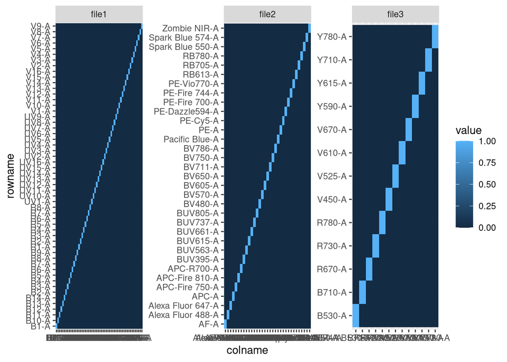

```r
list(file1 = flow_frame1, file2 = flow_frame2, file3 = flow_frame3) %>%
    map(get_spill) %>%
    map(tidy_spill) %>%
    bind_rows(.id = "file") %>%
    ggplot(aes(x = colname, y = rowname, fill=value)) +
    geom_raster() +
    facet_wrap(~file, scale="free")
```

Why are the spill matrices equal to the identity matrix? Shouldn’t at least the conventional flow frame (file 3) need it for computing compensation?

## Problem 3

> If you have access to commercial software, take one of the .fcs files and try to see if you can see similar internal information from within the software. For those without commercial access, try the equivalent process using Floreada.io.

I used Floreada.io.

By right clicking the filename a menu appears:

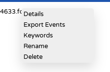

Not much details:

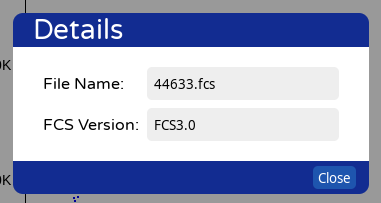

A list of all keywords:

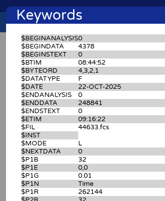

By selecting the Export events choice the actual intensities can be saved to a spreadsheet file or opened in a spreadsheet program.